# Inside Context Memory

> This notebook focuses on context memory Inside the rooms.

# 1 Overview of the data

The rooms were separated into *Familiar* and *Novel* groups. Participants explored the *Familiar* group at the beginning of the experiment. In the encoding task, they visisted both *Familiar* and *Novel* groups. Their context memory (i.e., in which room they saw the item) was tested in the memory test the next day of the encoding task. **Novelty benefits** on the context memory are examined by comparing the memory performance between the *Familiar* and *Novel* groups.

Participants were also asked to rate how curious they felt about the room. The higher the rating is means they felt more curious about the room. Context memory as a function of curiosity rating was also examined for **curiosity benefits**.

Questionnaires on personal traits regarding curiosity were also administered to participants before the encoding task (i.e., PC and EC). Scores on these questionnaires might be able to predict the context memory or its relationship with curiosity rating.

In the encoding task, there were 6 objects outside each room. It is possbile that the context memory for the object to some extent depends on the order in which the object was seen. For example, it may be easier to remember where the first and last objects were seen as compared to those in the middle. Particularly, if the participant became more curious when getting closer to the room, then one would expect that the performance increases as a function of item order.

# 2 Individual performance

## 2.1 An overview of individual context memory performance as a function of room.

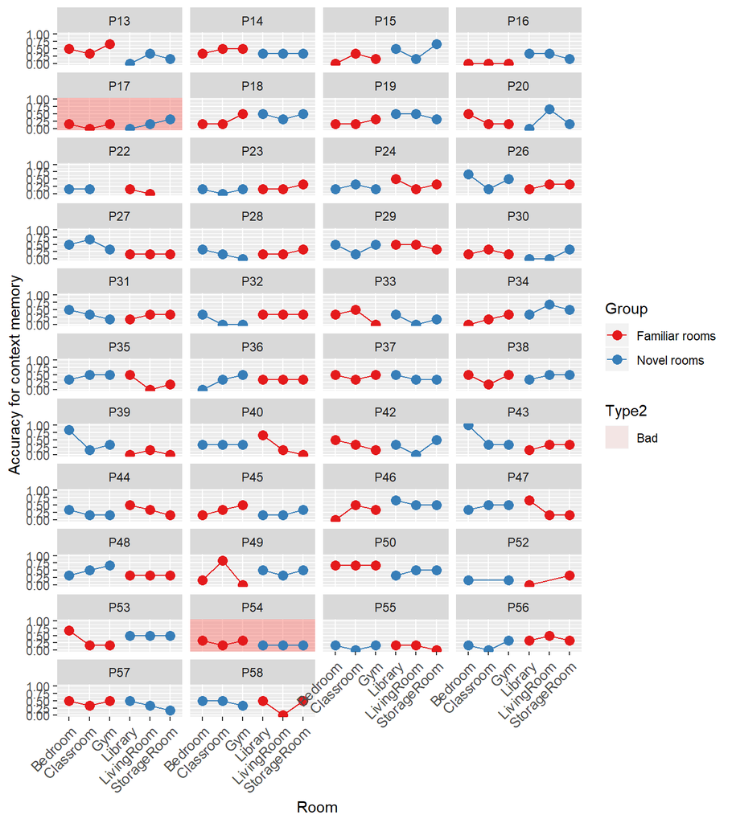

Figure 1. Mean accuracy for context memory respectively for each room and each individual participant.

# 3 Novelty Benefits

We predicted that the context memory should be better for the *novel* rooms than for the *familiar* rooms.

## 3.1 Compare mean corrected hit rate between *novel* and *familiar* rooms

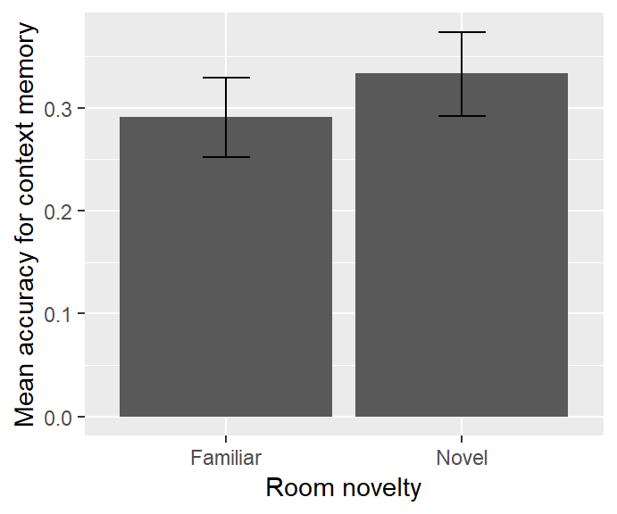

Figure 2. Mean accuracy for context memory respectively for Familiar and Novel rooms.

```
##
##  Paired t-test
##
## data:  MeanCorrContextAccuracy by Group
## t = -1.4984, df = 39, p-value = 0.1421
## alternative hypothesis: true difference in means is not equal to 0
## 95 percent confidence interval:
##  -0.09954610  0.01482388
## sample estimates:
## mean of the differences
##             -0.04236111
```

## 3.2 Context memory as a function of item order

### 3.2.1 Visualise the data

#### 3.2.1.1 Nonlinear

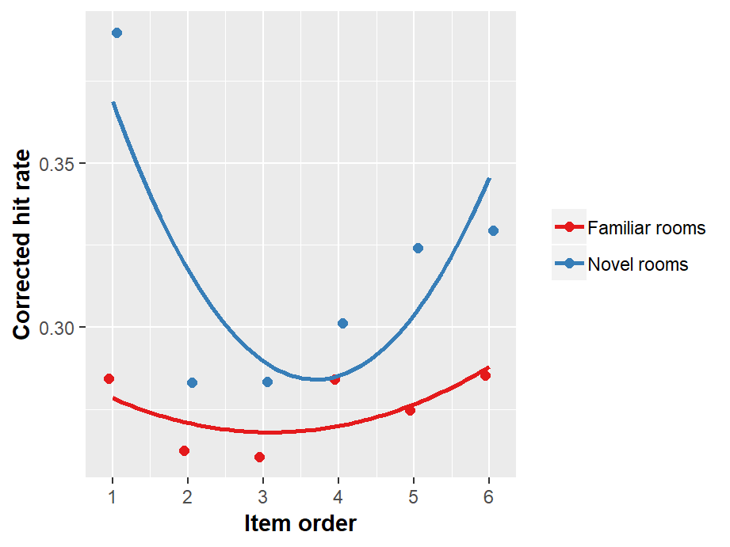

#### 3.2.1.2 Linear

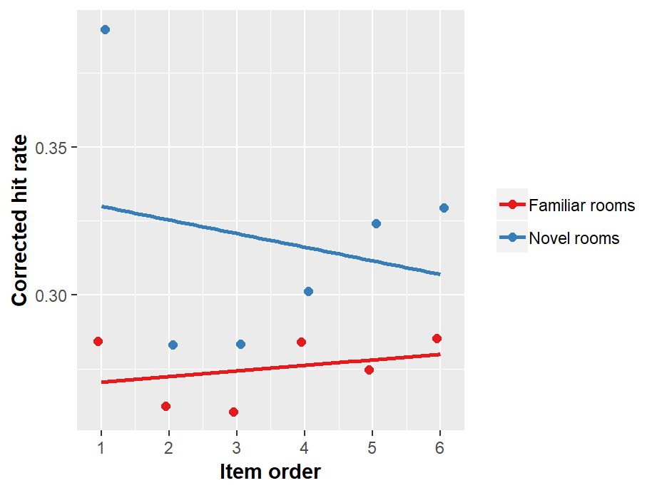

### 3.2.2 Testing novelty effect as a function of item order

Build models with corrected hit rate as $y$ and then examine effects of item order and novelty by comparing the models.

- `baseline.context` is the model with only an intercept.
- `order.model.linear.1` is the model with $\small ItemOrder$ included, showing the effects of item order.
- `order.model.linear.2` is the model allowing the slope (i.e., relationship between context memory and item order) varying across participants.
- `order.model.quad.1` and `order.model.quad.2` repectively included $\small ItemOrder^2$ and related random effects.
- `novelty.model.1` is the model with $\small Group$ (i.e., *familiar* and *novel* rooms) included, examining the effects of novelty of the rooms on the intercept (i.e., mean context memory accuracy at the 1st order or overall if no difference in slope).
- `novelty.model.2` is the model with interaction between $\small Group$ and $\small ItemOrder$ included, examining the effects of novelty on how context memory accuracy changes as a function of item order.
- `novelty.model.3` included interaction between $\small Group$ and $\small ItemOrder^2$ for inestigating whether the pattern changes between *familiar* and *novel* groups.

```
##                      Model df      AIC      BIC    logLik   Test   L.Ratio
## baseline.context         1  4 112.3014 128.9966 -52.15071
## order.model.linear.1     2  5 114.2634 135.1323 -52.13168 1 vs 2 0.0380703
## order.model.quad.1       3  6 114.1075 139.1502 -51.05375 2 vs 3 2.1558437
## novelty.model.1          4  7 113.8481 143.0646 -49.92405 3 vs 4 2.2594178
## novelty.model.2          5  8 115.6300 149.0203 -49.81503 4 vs 5 0.2180364
## novelty.model.3          6  9 116.6821 154.2462 -49.34108 5 vs 6 0.9479014
##                      p-value
## baseline.context
## order.model.linear.1  0.8453
## order.model.quad.1    0.1420
## novelty.model.1       0.1328
## novelty.model.2       0.6405
## novelty.model.3       0.3303
```

There was no significant interaction, either linear or quadratic.

#### 3.2.2.1 Parameter estimation for the complete model

```
##                                Value   Std.Error  DF    t-value
## (Intercept)              0.368636342 0.039252622 396  9.3913814
## ItemOrderCt             -0.062606028 0.035157002 396 -1.7807556
## I(ItemOrderCt^2)         0.011602086 0.006749324 396  1.7189998
## Group1                  -0.090122204 0.055097155  39 -1.6356961
## ItemOrderCt:Group1       0.052674142 0.049719509 396  1.0594260
## I(ItemOrderCt^2):Group1 -0.009239429 0.009544985 396 -0.9679877
##                              p-value
## (Intercept)             4.752454e-19
## ItemOrderCt             7.571889e-02
## I(ItemOrderCt^2)        8.639590e-02
## Group1                  1.099497e-01
## ItemOrderCt:Group1      2.900516e-01
## I(ItemOrderCt^2):Group1 3.336413e-01
```

### 3.2.3 Collapse the order

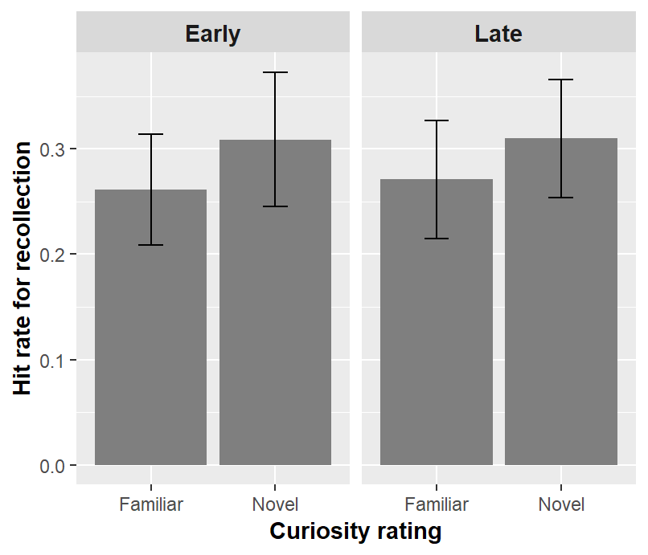

#### 3.2.3.1 Stats on it

```
##                  Model df       AIC       BIC   logLik   Test   L.Ratio
## baseline             1  5 -91.72288 -76.34701 50.86144
## noveltyModel         2  6 -91.77985 -73.32881 51.88993 1 vs 2 2.0569691
## orderModel           3  7 -89.82689 -68.30067 51.91345 2 vs 3 0.0470401
## interactionModel     4  8 -87.85829 -63.25690 51.92914 3 vs 4 0.0313989
##                  p-value
## baseline
## noveltyModel      0.1515
## orderModel        0.8283
## interactionModel  0.8594
```

No main effects.

# 4 Curiosity Benefits

Here I checked how accurach of context memory changes as a function of curiosity rating. We hypothesised that the more curiosity the participant felt about the room (higher ratings) the better the context memory.

## 4.1 Mean accuracy of context memory as a function of curiosity rating

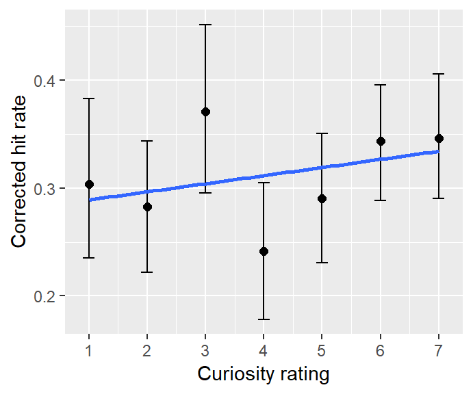

Figure 4. Mean accuracy for context memory as a function of curiosity rating.

### 4.1.1 Testing the relationship between context memory and curiosity rating

Build models with corrected hit rate as $y$ and cexamine effects of curiosity rating by including it into the model and then comparing the model fits.

- `baseline.rating` is the model with only an intercept, showing no change in context memory as a function of curiosity rating.
- `rating.intercept` is the model with $\small CuriosityRating$ included, showing the effects of curiosity rating.
- `rating.slope` is the model allowing the slope (i.e., relationship between context memory and curiosity rating) varying across participants.

```
##                  Model df        AIC       BIC   logLik   Test  L.Ratio
## baseline.rating      1  3 -100.75356 -90.36206 53.37678
## rating.intercept     2  4 -100.43340 -86.57808 54.21670 1 vs 2 1.679846
## rating.slope         3  6  -97.68123 -76.89823 54.84061 2 vs 3 1.247821
##                  p-value
## baseline.rating
## rating.intercept  0.1949
## rating.slope      0.5358
```

Correlation was not significant.

### 4.1.2 Using normalised curiosity ratings.

```
##                  Model df       AIC       BIC   logLik   Test  L.Ratio
## baseline.rating      1  3 -100.7536 -90.36206 53.37678
## rating.intercept     2  4 -101.8788 -88.02351 54.93942 1 vs 2 3.125273
## rating.slope         3  6 -102.7145 -81.93152 57.35725 2 vs 3 4.835674
##                  p-value
## baseline.rating
## rating.intercept  0.0771
## rating.slope      0.0891
```

```r
options(digits = 4)
summary(rating.slope)$tTable
```

```
##                    Value Std.Error  DF t-value   p-value
## (Intercept)      0.31396   0.01521 195  20.639 6.200e-51
## NCuriosityRating 0.02343   0.01606 195   1.459 1.461e-01
```

Unfortunately, not significant.

## 4.2 Does the relationship with curiosity rating depend on item order?

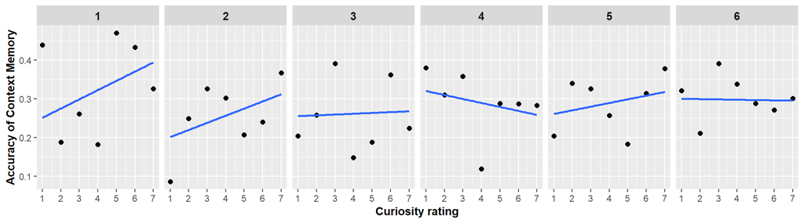

Figure 5. Mean corrected hit rate across participants for context memory as a function of curiosity rating for each order at which the item was seen (I.e., 1st, 2nd, 3rd, etc.).

### 4.2.1 Testing the effect of item order

Build models with corrected hit rate as $y$ and examine effects of curioity rating and item order by comparing the models.

```r
baseline.context <- lme(CorrContextAccuracy ~ 1, random = ~ 1|SubjectNo, data = Encoding.Recall.Old[!SubjectNo %in% bad.ps.less.strict], method = "ML", control = list(msMaxIter = 500, opt = "optim", msVerbose=FALSE), na.action = na.exclude)

rating.intercept <- update(baseline.context, .~. + CuriosityRating)
rating.slope     <- update(rating.intercept, random = ~ 1 + CuriosityRating | SubjectNo)

item.model.linear.1     <- update(rating.slope, .~. + ItemOrder)
item.model.linear.2     <- update(item.model.linear.1, random = ~1+CuriosityRating+ItemOrder|SubjectNo)
item.model.linear.3     <- update(item.model.linear.2, .~. + ItemOrder : CuriosityRating)

# item.model.quad.1       <- update(item.model.linear.3, .~. + I(ItemOrder^2))
# item.model.quad.2       <- update(item.model.quad.1,   random = list(~1+CuriosityRating|SubjectNo, ~1+ItemOrder+I(ItemOrder^2)|SubjectNo)) # excluding this model because singularity issue (perhaps the model was getting too complex to be calculated)
# item.model.quad.3       <- update(item.model.quad.1,   .~. + I(ItemOrder^2) : CuriosityRating)

anova(baseline.context, rating.intercept, rating.slope, item.model.linear.1,item.model.linear.2,  item.model.linear.3)
```

```
##                     Model df  AIC  BIC logLik   Test L.Ratio p-value
## baseline.context        1  3 1860 1876 -927.1
## rating.intercept        2  4 1861 1882 -926.3 1 vs 2  1.4997  0.2207
## rating.slope            3  6 1863 1894 -925.4 2 vs 3  1.8429  0.3979
## item.model.linear.1     4  7 1865 1902 -925.4 3 vs 4  0.0835  0.7726
## item.model.linear.2     5 10 1870 1922 -924.9 4 vs 5  1.0021  0.8007
## item.model.linear.3     6 11 1870 1928 -924.2 5 vs 6  1.4459  0.2292
```

Nothing significant.

### 4.2.2 Collapse the order and curiosity rating

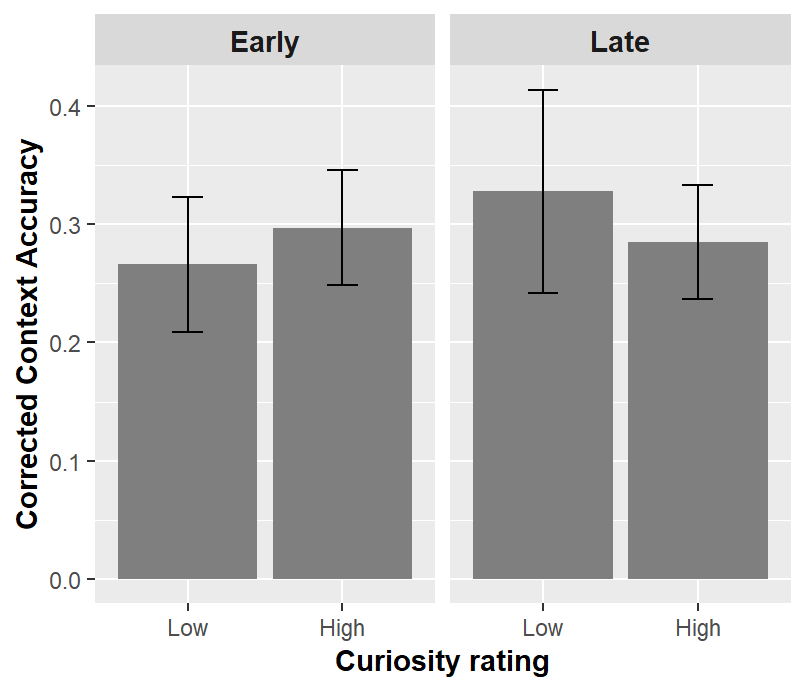

Figure 6. Mean corrected hit rate as a function of item order (Early vs. Late) and curiosity (Low vs. High).

#### 4.2.2.1 Stats on it

```
##                  Model df    AIC    BIC logLik   Test L.Ratio p-value
## baseline             1  5 -81.54 -66.42  45.77
## curiosityModel       2  6 -79.56 -61.42  45.78 1 vs 2  0.0235  0.8782
## orderModel           3  7 -78.39 -57.23  46.20 2 vs 3  0.8299  0.3623
## interactionModel     4  8 -78.61 -54.42  47.30 3 vs 4  2.2138  0.1368
```

No main effects or interaction.

#### 4.2.2.2 Linear trend respectivley for High and Low curiosity groups

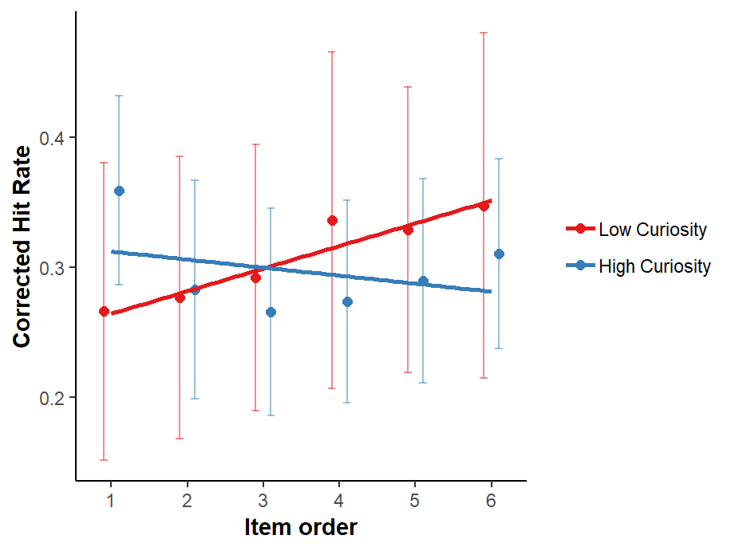

```r
Encoding.Recall.Old.CuriosityType$ItemOrderCt <- Encoding.Recall.Old.CuriosityType$ItemOrder - 1

baseline <- lme(CorrContextAccuracy ~ 1, random = ~ 1|SubjectNo/CuriosityRatingType, data = Encoding.Recall.Old.CuriosityType[!SubjectNo %in% bad.ps.less.strict], method = "ML", control = list(msMaxIter = 500, opt = "optim", msVerbose=FALSE), na.action = na.exclude)

orderModel.linear.1   <- update(baseline,              .~. + ItemOrderCt)
orderModel.linear.2   <- update(orderModel.linear.1,   random = ~ 1 + ItemOrderCt|SubjectNo/CuriosityRatingType)

curiosityModel        <- update(orderModel.linear.2,   .~. + CuriosityRatingType)
curiosityModel.linear <- update(curiosityModel,        .~. + CuriosityRatingType : ItemOrderCt)

anova(baseline, orderModel.linear.1, orderModel.linear.2, curiosityModel, curiosityModel.linear)
```

```
##                       Model df   AIC   BIC logLik   Test L.Ratio p-value
## baseline                  1  4 177.5 194.0 -84.77
## orderModel.linear.1       2  5 179.1 199.7 -84.56 1 vs 2  0.4192  0.5173
## orderModel.linear.2       3  9 184.3 221.4 -83.16 2 vs 3  2.8055  0.5909
## curiosityModel            4 10 186.3 227.5 -83.15 3 vs 4  0.0040  0.9496
## curiosityModel.linear     5 11 186.2 231.6 -82.11 4 vs 5  2.0862  0.1486
```

No significant main effects.

### 4.2.3 Try another way to calculate “High” and “Low” curiosity groups

> “High” - higher than mean; “Low” - lower than mean

#### 4.2.3.1 Compare “High” and “Low” groups

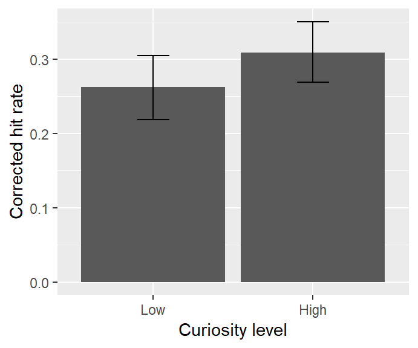

```
##
##  Paired t-test
##
## data:  CorrContextAccuracy by RatingGroup
## t = -1.6, df = 39, p-value = 0.1
## alternative hypothesis: true difference in means is not equal to 0
## 95 percent confidence interval:
##  -0.10656  0.01353
## sample estimates:
## mean of the differences
##                -0.04651
```

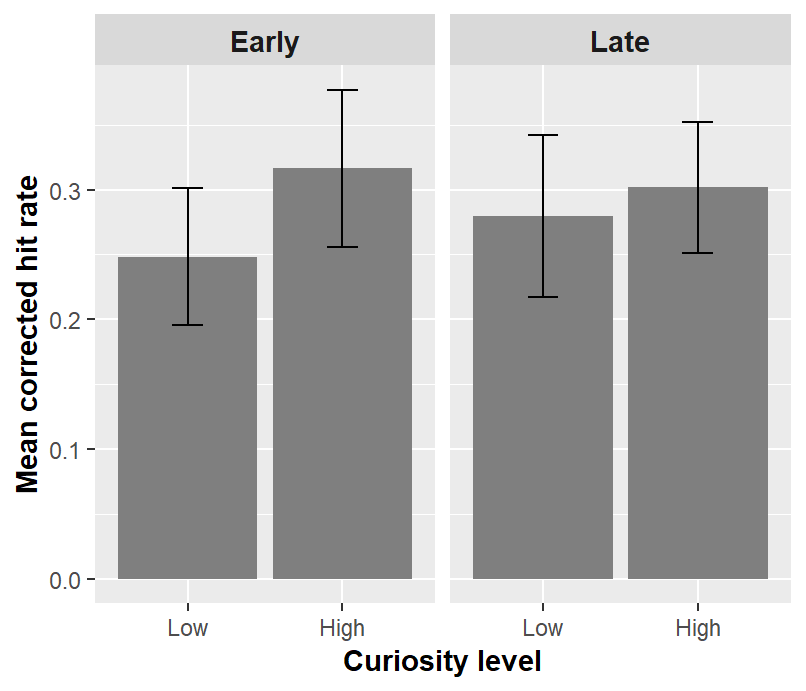

#### 4.2.3.2 Stats on it

```
##                  Model df    AIC    BIC logLik   Test L.Ratio p-value
## baseline             1  5 -94.09 -78.71  52.04
## curiosityModel       2  6 -94.41 -75.96  53.21 1 vs 2  2.3264  0.1272
## orderModel           3  7 -92.52 -71.00  53.26 2 vs 3  0.1089  0.7414
## interactionModel     4  8 -91.37 -66.77  53.69 3 vs 4  0.8514  0.3562
```

No main effects or interaction.

#### 4.2.3.3 Linear trend respectivley for High and Low curiosity groups

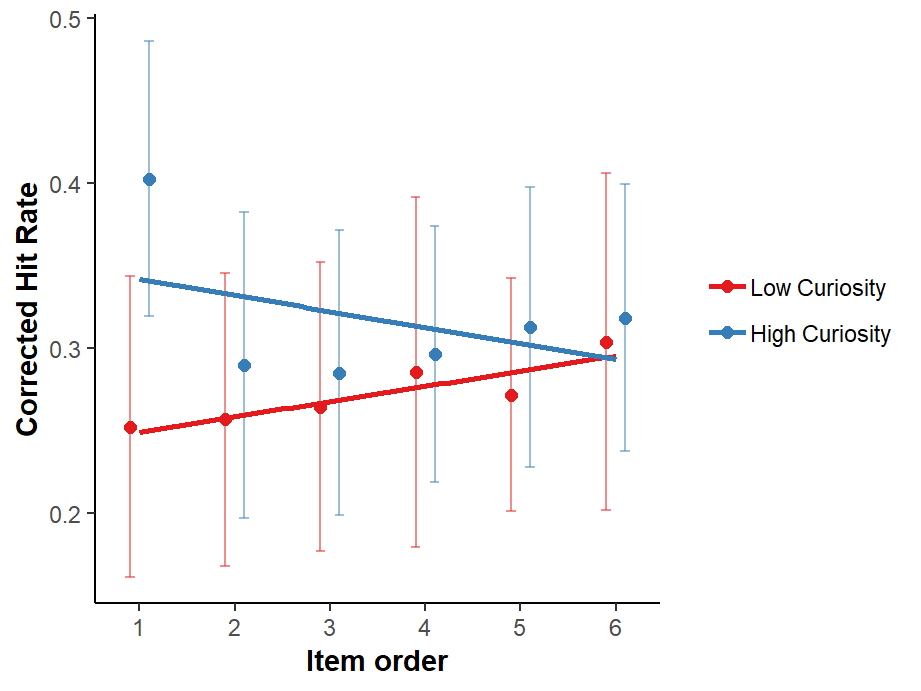

```r
Encoding.Recall.Old.CuriosityType.MeanSep$ItemOrderCt <- Encoding.Recall.Old.CuriosityType.MeanSep$ItemOrder - 1

baseline <- lme(CorrContextAccuracy ~ 1, random = ~ 1|SubjectNo/RatingGroup, data = Encoding.Recall.Old.CuriosityType.MeanSep[!SubjectNo %in% bad.ps.less.strict], method = "ML", control = list(msMaxIter = 500, opt = "optim", msVerbose=FALSE), na.action = na.exclude)

orderModel.linear.1   <- update(baseline,              .~. + ItemOrderCt)
# orderModel.linear.2   <- update(orderModel.linear.1,   random = ~ 1 + ItemOrderCt|SubjectNo/RatingGroup)

curiosityModel        <- update(orderModel.linear.1,   .~. + RatingGroup)
curiosityModel.linear <- update(curiosityModel,        .~. + RatingGroup : ItemOrderCt)

anova(baseline, orderModel.linear.1, curiosityModel, curiosityModel.linear)
```

```
##                       Model df   AIC   BIC logLik   Test L.Ratio p-value
## baseline                  1  4 124.5 141.2 -58.23
## orderModel.linear.1       2  5 126.5 147.3 -58.23 1 vs 2  0.0013  0.9710
## curiosityModel            3  6 125.9 151.0 -56.97 2 vs 3  2.5263  0.1120
## curiosityModel.linear     4  7 126.1 155.3 -56.06 3 vs 4  1.8152  0.1779
```

No significant effect or interaction.

# 5 Curiosity and novelty

## 5.1 Testing the effects of curiosity rating and novelty together

Build models with corrected hit rate as $y$ and examine effects of curiosity rating and novelty together by including them into the model separately and then comparing the model fits.

```
##                   Model df    AIC    BIC logLik   Test L.Ratio p-value
## baseline.rating       1  4 -102.9 -89.06  55.46
## rating.intercept      2  5 -102.0 -84.67  55.99 1 vs 2   1.079  0.2989
## novelty.model.1       3  6 -101.1 -80.32  56.55 2 vs 3   1.113  0.2913
## interaction.model     4  7 -100.8 -76.61  57.43 3 vs 4   1.749  0.1860
```

### 5.1.1 Check the complete model

```
## Linear mixed-effects model fit by maximum likelihood
##  Data: InsideObjectsMemory[!SubjectNo %in% bad.ps.less.strict]
##      AIC    BIC logLik
##   -100.9 -76.61  57.43
##
## Random effects:
##  Formula: ~1 | SubjectNo
##         (Intercept)
## StdDev:     0.03384
##
##  Formula: ~1 | Group %in% SubjectNo
##         (Intercept) Residual
## StdDev:     0.07422   0.1744
##
## Fixed effects: CorrContextAccuracy ~ CuriosityRating + Group + CuriosityRating:Group
##                              Value Std.Error  DF t-value p-value
## (Intercept)                 0.3237   0.04370 154   7.409  0.0000
## CuriosityRating            -0.0103   0.01287 154  -0.804  0.4226
## GroupNovel                 -0.0980   0.11576  39  -0.847  0.4022
## CuriosityRating:GroupNovel  0.0289   0.02203 154   1.314  0.1909
##  Correlation:
##                            (Intr) CrstyR GrpNvl
## CuriosityRating            -0.880
## GroupNovel                 -0.369  0.328
## CuriosityRating:GroupNovel  0.511 -0.581 -0.933
##
## Standardized Within-Group Residuals:
##       Min        Q1       Med        Q3       Max
## -1.934331 -0.677327  0.003863  0.645225  3.227897
##
## Number of Observations: 236
## Number of Groups:
##            SubjectNo Group %in% SubjectNo
##                   40                   80
```

## 5.2 What about the other way around

```
##                   Model df  AIC  BIC logLik   Test L.Ratio p-value
## baseline.context      1  3 1860 1876 -927.1
## novelty.model.1       2  4 1859 1880 -925.5 1 vs 2   3.222  0.0726
## rating.model.1        3  5 1861 1887 -925.4 2 vs 3   0.082  0.7740
## rating.model.2        4 10 1866 1919 -923.1 3 vs 4   4.638  0.4616
## interaction.model     5 11 1867 1925 -922.6 4 vs 5   1.013  0.3141
```

## 5.3 Check the collapsed data

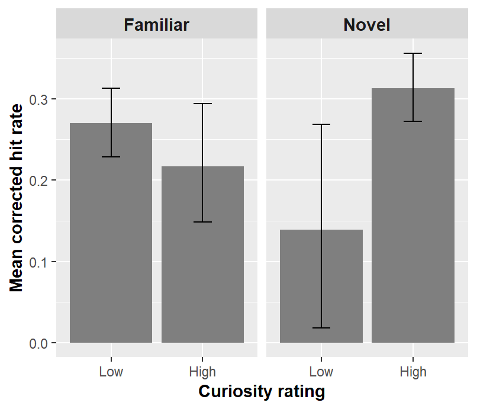

Big differences in sample size between conditions, so hard to calculate.

# 6 Curiosity effects in the *Novel* group

## 6.1 Mean accuracy of item memory as a function of curiosity rating

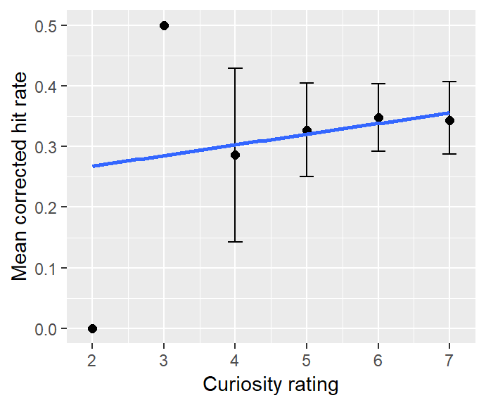